# TADPOLE_Survival

Jose Tamez

2023-01-19

# 1 TADPOLE Univariate

### 1.0.1 The run options

```r
TrainFraction <- 0.50;
sig_pvalue <- 0.01
thr <- c(0.05,0.2,0.4,0.6,0.8,0.95);
method  <- c("fast","pearson","spearman","kendall");
type <- c("LM","RLM")
DeOutcome <- c("NoDriven","Driven")
corRankS <- c("FALSE","TRUE")

thr <- thr[4]
method  <- method[1]
type <- type[1]
DeOutcome <- DeOutcome[2]
corRankS <- corRankS[2]


corRank <- corRankS == "TRUE"
```

### 1.0.2 Loading the libraries

```r
library("FRESA.CAD")
library(readxl)
library("whitening")
library("fpc")
library("robust")
op <- par(no.readonly = TRUE)
pander::panderOptions('digits', 3)
pander::panderOptions('table.split.table', 400)
pander::panderOptions('keep.trailing.zeros',TRUE)
```

## 1.1 The data set

```r
TADPOLE_D1_D2 <- read.csv("~/GitHub/BSWiMS/Data/TADPOLE/TADPOLE_D1_D2.csv")
TADPOLE_D1_D2_Dict <- read.csv("~/GitHub/BSWiMS/Data/TADPOLE/TADPOLE_D1_D2_Dict.csv")
TADPOLE_D1_D2_Dict_LR <- as.data.frame(read_excel("~/GitHub/BSWiMS/Data/TADPOLE/TADPOLE_D1_D2_Dict_LR.xlsx",sheet = "LeftRightFeatures"))


rownames(TADPOLE_D1_D2_Dict) <- TADPOLE_D1_D2_Dict$FLDNAME
```

## 1.2 Conditioning the data

```r
# mm3 to mm
isVolume <- c("Ventricles","Hippocampus","WholeBrain","Entorhinal","Fusiform","MidTemp","ICV",
              TADPOLE_D1_D2_Dict$FLDNAME[str_detect(TADPOLE_D1_D2_Dict$TEXT,"Volume")]
              )


#TADPOLE_D1_D2[,isVolume] <- apply(TADPOLE_D1_D2[,isVolume],2,'^',(1/3))
TADPOLE_D1_D2[,isVolume] <- TADPOLE_D1_D2[,isVolume]^(1/3)

# mm2 to mm
isArea <- TADPOLE_D1_D2_Dict$FLDNAME[str_detect(TADPOLE_D1_D2_Dict$TEXT,"Area")]
TADPOLE_D1_D2[,isArea] <- sqrt(TADPOLE_D1_D2[,isArea])

# Get only cross sectional measurements
FreeSurfersetCross <- str_detect(colnames(TADPOLE_D1_D2),"UCSFFSX")

# The subset of baseline measurements
baselineTadpole <- subset(TADPOLE_D1_D2,VISCODE=="bl")
table(baselineTadpole$DX)
```

```
                   Dementia Dementia to MCI             MCI MCI to Dementia
          7             336               1             864               5
  MCI to NL              NL       NL to MCI
          2             521               1
```

```r
table(baselineTadpole$DX_bl)
```

AD CN EMCI LMCI SMC 342 417 310 562 106

```r
rownames(baselineTadpole) <- baselineTadpole$PTID


validBaselineTadpole <- cbind(DX=baselineTadpole$DX_bl,
                                 AGE=baselineTadpole$AGE,
                                 Gender=1*(baselineTadpole$PTGENDER=="Female"),
                                 ADAS11=baselineTadpole$ADAS11,
                                 ADAS13=baselineTadpole$ADAS13,
                                 MMSE=baselineTadpole$MMSE,
                                 RAVLT_immediate=baselineTadpole$RAVLT_immediate,
                                 RAVLT_learning=baselineTadpole$RAVLT_learning,
                                 RAVLT_forgetting=baselineTadpole$RAVLT_forgetting,
                                 RAVLT_perc_forgetting=baselineTadpole$RAVLT_perc_forgetting,
                                 FAQ=baselineTadpole$FAQ,
                                 Ventricles=baselineTadpole$Ventricles,
                                 Hippocampus=baselineTadpole$Hippocampus,
                                 WholeBrain=baselineTadpole$WholeBrain,
                                 Entorhinal=baselineTadpole$Entorhinal,
                                 Fusiform=baselineTadpole$Fusiform,
                                 MidTemp=baselineTadpole$MidTemp,
                                 ICV=baselineTadpole$ICV,
                                 baselineTadpole[,FreeSurfersetCross])


LeftFields <- TADPOLE_D1_D2_Dict_LR$LFN
names(LeftFields) <- LeftFields
LeftFields <- LeftFields[LeftFields %in% colnames(validBaselineTadpole)]
RightFields <- TADPOLE_D1_D2_Dict_LR$RFN
names(RightFields) <- RightFields
RightFields <- RightFields[RightFields %in% colnames(validBaselineTadpole)]

## Normalize to ICV
validBaselineTadpole$Ventricles=validBaselineTadpole$Ventricles/validBaselineTadpole$ICV
validBaselineTadpole$Hippocampus=validBaselineTadpole$Hippocampus/validBaselineTadpole$ICV
validBaselineTadpole$WholeBrain=validBaselineTadpole$WholeBrain/validBaselineTadpole$ICV
validBaselineTadpole$Entorhinal=validBaselineTadpole$Entorhinal/validBaselineTadpole$ICV
validBaselineTadpole$Fusiform=validBaselineTadpole$Fusiform/validBaselineTadpole$ICV
validBaselineTadpole$MidTemp=validBaselineTadpole$MidTemp/validBaselineTadpole$ICV

leftData <- validBaselineTadpole[,LeftFields]/validBaselineTadpole$ICV
RightData <- validBaselineTadpole[,RightFields]/validBaselineTadpole$ICV

## get mean and relative difference
meanLeftRight <- (leftData + RightData)/2
difLeftRight <- abs(leftData - RightData)
reldifLeftRight <- difLeftRight/meanLeftRight
colnames(meanLeftRight) <- paste("M",colnames(meanLeftRight),sep="_")
colnames(difLeftRight) <- paste("D",colnames(difLeftRight),sep="_")
colnames(reldifLeftRight) <- paste("RD",colnames(reldifLeftRight),sep="_")


validBaselineTadpole <- validBaselineTadpole[,!(colnames(validBaselineTadpole) %in%
                                               c(LeftFields,RightFields))]
#validBaselineTadpole <- cbind(validBaselineTadpole,meanLeftRight,difLeftRight,reldifLeftRight)
validBaselineTadpole <- cbind(validBaselineTadpole,meanLeftRight,difLeftRight)

## Remove columns with too many NA more than %15 of NA
nacount <- apply(is.na(validBaselineTadpole),2,sum)/nrow(validBaselineTadpole) < 0.15
diagnose <- validBaselineTadpole$DX
pander::pander(table(diagnose))
```

| AD | CN | EMCI | LMCI | SMC |
| --- | --- | --- | --- | --- |
| 342 | 417 | 310 | 562 | 106 |

```r
validBaselineTadpole <- validBaselineTadpole[,nacount]
## Remove character columns
ischar <- sapply(validBaselineTadpole,class) == "character"
validBaselineTadpole <- validBaselineTadpole[,!ischar]
## Place back diagnose
validBaselineTadpole$DX <- diagnose


validBaselineTadpole <- validBaselineTadpole[complete.cases(validBaselineTadpole),]
ischar <- sapply(validBaselineTadpole,class) == "character"
validBaselineTadpole[,!ischar] <- sapply(validBaselineTadpole[,!ischar],as.numeric)

colnames(validBaselineTadpole) <- str_remove_all(colnames(validBaselineTadpole),"_UCSFFSX_11_02_15_UCSFFSX51_08_01_16")
colnames(validBaselineTadpole) <- str_replace_all(colnames(validBaselineTadpole)," ","_")
validBaselineTadpole$LONISID <- NULL
validBaselineTadpole$IMAGEUID <- NULL
validBaselineTadpole$LONIUID <- NULL

diagnose <- as.character(validBaselineTadpole$DX)
validBaselineTadpole$DX <- diagnose
pander::pander(table(validBaselineTadpole$DX))
```

| AD | CN | EMCI | LMCI | SMC |
| --- | --- | --- | --- | --- |
| 245 | 359 | 272 | 444 | 93 |

```r
validBaselineTadpole[validBaselineTadpole$DX %in% c("EMCI","LMCI"),"DX"] <- "MCI"
validBaselineTadpole[validBaselineTadpole$DX %in% c("CN","SMC"),"DX"] <- "NL"

pander::pander(table(validBaselineTadpole$DX))
```

| AD | MCI | NL |
| --- | --- | --- |
| 245 | 716 | 452 |

## 1.3 Get the Time To Event on MCI Subjects

```r
subjectsID <- rownames(validBaselineTadpole)
visitsID <- unique(TADPOLE_D1_D2$VISCODE)
baseDx <- TADPOLE_D1_D2[TADPOLE_D1_D2$VISCODE=="bl",c("PTID","DX","EXAMDATE")]
rownames(baseDx) <- baseDx$PTID
baseDx <- baseDx[subjectsID,]
lastDx <- baseDx
toDementia <- baseDx
table(lastDx$DX)
```

```
   Dementia Dementia to MCI             MCI MCI to Dementia       MCI to NL
        244               1             711               2               2
         NL       NL to MCI
        452               1
```

```r
hasDementia <- lastDx$PTID[str_detect(lastDx$DX,"Dementia")]


for (vid in visitsID)
{
  DxValue <- TADPOLE_D1_D2[TADPOLE_D1_D2$VISCODE==vid,c("PTID","DX","EXAMDATE")]
  rownames(DxValue) <- DxValue$PTID
  DxValue <- DxValue[DxValue$PTID %in% subjectsID,]
  noDX <- DxValue$PTID[nchar(DxValue$DX) < 1]
  print(length(noDX))
  DxValue[noDX,] <- lastDx[noDX,]
  inLast <- lastDx$PTID[lastDx$PTID %in% DxValue$PTID]
  print(length(inLast))
  lastDx[inLast,] <- DxValue[inLast,]
  noDementia <- !(toDementia$PTID %in% hasDementia)
  toDementia[noDementia,] <- lastDx[noDementia,]
  hasDementia <- unique(c(hasDementia,lastDx$PTID[str_detect(lastDx$DX,"Dementia")]))
}
```

[1] 0 [1] 1413 [1] 2 [1] 1326 [1] 6 [1] 1218 [1] 23 [1] 1095 [1] 805 [1] 1058 [1] 29 [1] 710 [1] 20 [1] 212 [1] 14 [1] 167 [1] 32 [1] 553 [1] 25 [1] 298 [1] 18 [1] 130 [1] 667 [1] 667 [1] 112 [1] 112 [1] 176 [1] 176 [1] 177 [1] 177 [1] 625 [1] 625 [1] 251 [1] 251 [1] 159 [1] 159 [1] 7 [1] 7 [1] 17 [1] 99 [1] 9 [1] 63 [1] 1 [1] 1

```r
table(lastDx$DX)
```

```
   Dementia Dementia to MCI             MCI MCI to Dementia       MCI to NL
        428               2             463              80               7
         NL  NL to Dementia       NL to MCI
        406               1              26
```

```r
baseMCI <-baseDx$PTID[baseDx$DX == "MCI"]
lastDementia <- lastDx$PTID[str_detect(lastDx$DX,"Dementia")]
lastDementia2 <- toDementia$PTID[str_detect(toDementia$DX,"Dementia")]
lastNL <- lastDx$PTID[str_detect(lastDx$DX,"NL")]

MCIatBaseline <- baseDx[baseMCI,]
MCIatEvent <- toDementia[baseMCI,]
MCIatLast <- lastDx[baseMCI,]

MCIconverters <- MCIatBaseline[baseMCI %in% lastDementia,]
MCI_No_converters <- MCIatBaseline[!(baseMCI %in% MCIconverters$PTID),]
MCIconverters$TimeToEvent <- (as.Date(toDementia[MCIconverters$PTID,"EXAMDATE"])
                                   - as.Date(MCIconverters$EXAMDATE))

sum(MCIconverters$TimeToEvent ==0)
```

[1] 0

```r
MCIconverters$AtEventDX <- MCIatEvent[MCIconverters$PTID,"DX"]
MCIconverters$LastDX <- MCIatLast[MCIconverters$PTID,"DX"]

MCI_No_converters$TimeToEvent <- (as.Date(lastDx[MCI_No_converters$PTID,"EXAMDATE"])
                                   - as.Date(MCI_No_converters$EXAMDATE))

MCI_No_converters$LastDX <- MCIatLast[MCI_No_converters$PTID,"DX"]

MCI_No_converters <- subset(MCI_No_converters,TimeToEvent > 0)
```

# 2 Prognosis MCI to AD Conversion

## 2.1 the set

```r
MCIPrognosisIDs <- c(MCIconverters$PTID,MCI_No_converters$PTID)

TADPOLECrossMRI <- validBaselineTadpole[MCIPrognosisIDs,]
table(TADPOLECrossMRI$DX)
```

MCI 680

```r
TADPOLECrossMRI$DX <- NULL
TADPOLECrossMRI$status <- 1*(rownames(TADPOLECrossMRI) %in% MCIconverters$PTID)
table(TADPOLECrossMRI$status)
```

0 1 436 244

```r
TADPOLECrossMRI$TimeToEvent <- numeric(nrow(TADPOLECrossMRI))
TADPOLECrossMRI[MCIconverters$PTID,"TimeToEvent"] <- MCIconverters$TimeToEvent
TADPOLECrossMRI[MCI_No_converters$PTID,"TimeToEvent"] <- MCI_No_converters$TimeToEvent



set.seed(1)
trainCases <- sample(nrow(TADPOLECrossMRI),nrow(TADPOLECrossMRI)*TrainFraction)

TADPOLE_Conv_TRAIN <- TADPOLECrossMRI[trainCases,]
TADPOLE_Conv_TEST <- TADPOLECrossMRI[-trainCases,]

pander::pander(table(TADPOLE_Conv_TRAIN$status))
```

| 0 | 1 |
| --- | --- |
| 218 | 122 |

```r
pander::pander(table(TADPOLE_Conv_TEST$status))
```

| 0 | 1 |
| --- | --- |
| 218 | 122 |

```r
surTimeTrain <- TADPOLE_Conv_TRAIN$TimeToEvent
surTimeTest <- TADPOLE_Conv_TEST$TimeToEvent


TADPOLE_Conv_TRAIN$TimeToEvent <- NULL
TADPOLE_Conv_TEST$TimeToEvent <- NULL
```

#### 2.1.0.1 Analysis parameters

```r
dataframe <- TADPOLE_Conv_TRAIN
dataframeTest <- TADPOLE_Conv_TEST
outcome <- "status"


univariate_columns <- c("caseMean","caseStd","controlMean","controlStd","controlKSP","cStatCorr","ZGLM","pvalue")
```

## 2.2 The features to analyze

```r
pander::pander(c(rows=nrow(dataframe),col=ncol(dataframe)-1))
```

| rows | col |
| --- | --- |
| 340 | 327 |

```r
pander::pander(table(dataframe[,outcome]))
```

| 0 | 1 |
| --- | --- |
| 218 | 122 |

```r
varlist <- colnames(dataframe)
varlist <- varlist[!(varlist %in% c(outcome,"TimeToEvent"))]
varlist <- as.data.frame(cbind(name=varlist,desc=varlist))
```

## 2.3 Univariate RAW

```r
dataframeTime <- cbind(dataframe,SurvTime=surTimeTrain)


univarTrain <- uniRankVar(varlist,
               paste("Surv(SurvTime,",outcome,")~1"),
               outcome,
               dataframeTime,
               categorizationType = "Raw",
               type = "COX",
               rankingTest = "Ztest",
                uniType = "Binary",
               timeOutcome="SurvTime")
```

100 : M_ST24SA 200 : D_ST49TA 300 : D_ST47CV

```r
univarTrain$orderframe$pvalue=pnorm(abs(univarTrain$orderframe$ZGLM),lower.tail = FALSE)

pander::pander(univarTrain$orderframe[1:10,univariate_columns])
```

|  | caseMean | caseStd | controlMean | controlStd | controlKSP | cStatCorr | ZGLM | pvalue |
| --- | --- | --- | --- | --- | --- | --- | --- | --- |
| **ADAS13** | 20.7239 | 5.82768 | 13.7246 | 5.61367 | 2.72e-01 | 0.216 | 11.00 | 2.00e-28 |
| **FAQ** | 5.5410 | 4.71528 | 1.9404 | 2.86744 | 5.25e-13 | 0.249 | 9.80 | 5.49e-23 |
| **ADAS11** | 12.6666 | 4.41725 | 8.6145 | 3.87758 | 6.14e-02 | 0.252 | 9.68 | 1.89e-22 |
| **M_ST12SV** | 0.0910 | 0.00572 | 0.0967 | 0.00539 | 3.27e-01 | 0.718 | -8.28 | 5.93e-17 |
| **RAVLT_immediate** | 28.7049 | 7.96240 | 37.6468 | 10.73257 | 2.47e-01 | 0.733 | -8.15 | 1.79e-16 |
| **Hippocampus** | 0.1582 | 0.00918 | 0.1668 | 0.00909 | 6.11e-01 | 0.710 | -8.04 | 4.42e-16 |
| **M_ST29SV** | 0.1252 | 0.00736 | 0.1324 | 0.00716 | 6.90e-01 | 0.706 | -8.03 | 4.94e-16 |
| **M_ST13TA** | 0.0192 | 0.00178 | 0.0208 | 0.00172 | 4.11e-01 | 0.718 | -7.71 | 6.40e-15 |
| **M_ST40CV** | 0.1805 | 0.00877 | 0.1878 | 0.00768 | 4.91e-01 | 0.698 | -7.66 | 9.65e-15 |
| **M_ST24CV** | 0.0995 | 0.00807 | 0.1060 | 0.00688 | 2.65e-01 | 0.693 | -7.47 | 3.99e-14 |

```r
dataframeTime <- cbind(dataframeTest,SurvTime=surTimeTest)


univar <- uniRankVar(varlist,
               paste("Surv(SurvTime,",outcome,")~1"),
               outcome,
               dataframeTime,
               categorizationType = "Raw",
               type = "COX",
               rankingTest = "Ztest",
                uniType = "Binary",
               timeOutcome="SurvTime")
```

100 : M_ST24SA 200 : D_ST49TA 300 : D_ST47CV

```r
univar$orderframe$pvalue=pnorm(abs(univar$orderframe$ZGLM),lower.tail = FALSE)
```

===================================================================================================================

## 2.4 Decorrelation Analysis

```r
if (DeOutcome != "Driven")
{
  DEdataframeTrain <- GDSTMDecorrelation(dataframe,thr=thr,method=method,type=type,corRank=corRank,verbose = TRUE)
} else
{
  DEdataframeTrain <- GDSTMDecorrelation(dataframe,Outcome=outcome,thr=thr,method=method,type=type,corRank=corRank,verbose = TRUE)
}
```

Included: 284 , Uni p: 0.008732908 , Uncorrelated Base: 121 , Outcome-Driven Size: 29 , Base Size: 135

1 <R=1.000,w= 1,N= 6>, Top: 3( 1 )1 : 3 : 0.975,<|>Tot Used: 6 , Added: 3 , Zero Std: 0 , Max Cor: 0.950

2 <R=0.950,w= 1,N= 6>, Top: 1( 1 )1 : 1 : 0.950,<|>Tot Used: 8 , Added: 1 , Zero Std: 0 , Max Cor: 0.896

3 <R=0.896,w= 2,N= 0>

4 <R=0.896,w= 3,N= 19>, Top: 8( 1 )1 : 8 : 0.848,<|>Tot Used: 24 , Added: 8 , Zero Std: 0 , Max Cor: 0.896

5 <R=0.896,w= 3,N= 19>, Top: 1( 1 )1 : 1 : 0.848,<|>Tot Used: 26 , Added: 1 , Zero Std: 0 , Max Cor: 0.847

6 <R=0.847,w= 4,N= 58>, Top: 20( 2 )1 : 20 : 0.774,<|>Tot Used: 66 , Added: 24 , Zero Std: 0 , Max Cor: 0.914

7 <R=0.914,w= 4,N= 58>, Top: 5( 1 )1 : 5 : 0.807,<|>Tot Used: 74 , Added: 8 , Zero Std: 0 , Max Cor: 0.921

8 <R=0.921,w= 4,N= 58>, Top: 1( 1 )1 : 1 : 0.811,<|>Tot Used: 75 , Added: 1 , Zero Std: 0 , Max Cor: 0.806

9 <R=0.806,w= 5,N= 127>, Top: 325=2 : 32 : 0.671,<|>Tot Used: 150 , Added: 55 , Zero Std: 0 , Max Cor: 0.952

10 <R=0.952,w= 5,N= 127>, Top: 9( 1 )1 : 9 : 0.726,<|>Tot Used: 161 , Added: 9 , Zero Std: 0 , Max Cor: 0.724

11 <R=0.724,w= 6,N= 61>, Top: 17( 1 )1 : 17 : 0.600,<|>Tot Used: 179 , Added: 29 , Zero Std: 0 , Max Cor: 0.703

12 <R=0.703,w= 6,N= 61>, Top: 7( 1 )1 : 7 : 0.600,<|>Tot Used: 181 , Added: 9 , Zero Std: 0 , Max Cor: 0.815

13 <R=0.815,w= 6,N= 61>, Top: 2( 1 )1 : 2 : 0.600,<|>Tot Used: 181 , Added: 2 , Zero Std: 0 , Max Cor: 0.600

14 <R=0.000,w= 7,N= 0>-{ M_ST34TA M_ST39TA M_ST31TS M_ST23SA M_ST24SA M_ST38CV M_ST47CV M_ST54CV }-

[ 14 ], 0.5945127 Decor Dimension: 181 . Cor to Base: 88 , ABase: 33 , Outcome Base: 14

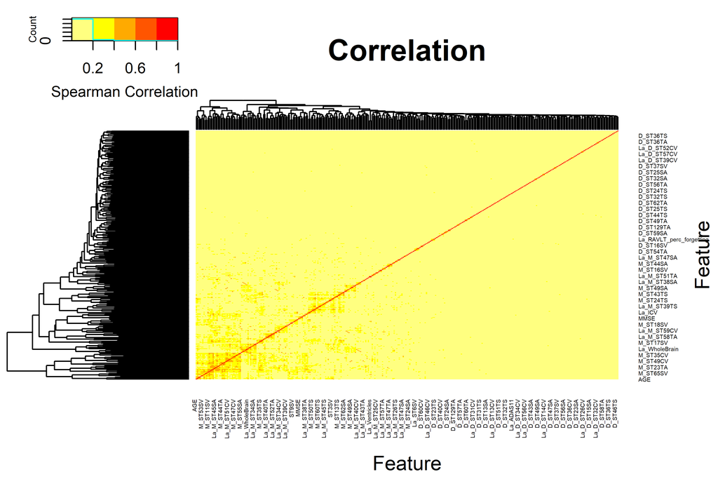

```r
cormat <- abs(cor(DEdataframeTrain[,colnames(DEdataframeTrain) != outcome],method="spearman"));

gplots::heatmap.2(abs(cormat),
                  trace = "none",
#                  scale = "row",
                  mar = c(5,5),
                  col=rev(heat.colors(5)),
                  main = "Correlation",
                  cexRow = 0.35,
                  cexCol = 0.35,
                  key.title=NA,
                  key.xlab="Spearman Correlation",
                  xlab="Feature", ylab="Feature")
```

```r
diag(cormat) <- 0;
pander::pander(max(cormat))
```

*0.799*

```r
demat <- attr(DEdataframeTrain,"GDSTM")
DEdataframe <- predictDecorrelate(DEdataframeTrain,dataframeTest)


pander::pander(c(Cols=ncol(demat),Rows=nrow(demat)))
```

| Cols | Rows |
| --- | --- |
| 181 | 181 |

```r
totFe <- ncol(DEdataframe)-1
totBa <- sum(str_detect(colnames(DEdataframe),"Ba_"))
totDe <- sum(str_detect(colnames(DEdataframe),"La_"))
toUnmat <- sum(apply(demat!=0,2,sum)==1)
unaltered <- totFe - ncol(demat) + toUnmat
pander::pander(c(Features=totFe,totBa=totBa,totDe=totDe,unaltered=totFe-totBa-totDe,totuna=unaltered))
```

| Features | totBa | totDe | unaltered | totuna |
| --- | --- | --- | --- | --- |
| 327 | 0 | 127 | 200 | 200 |

```r
pander::pander(c(Decorrleated_Fraction=sum(str_detect(colnames(DEdataframe),"La_"))/(ncol(DEdataframe)-1)))
```

| Decorrleated_Fraction |
| --- |
| 0.388 |

```r
pander::pander(c(Base_Fraction=sum(str_detect(colnames(DEdataframe),"Ba_"))/(ncol(DEdataframe)-1)))
```

| Base_Fraction |
| --- |
| 0 |

```r
pander::pander(c(Unaltered_Fraction=unaltered/totFe))
```

| Unaltered_Fraction |
| --- |
| 0.612 |

```r
pander::pander(c(sparcity=(totFe-ncol(demat)+sum(abs(demat)!=0))/totFe/totFe))
```

| sparcity |
| --- |
| 0.00452 |

```r
varlistDe <-  colnames(demat)[apply(demat!=0,2,sum)>1];
varlistDe <- as.data.frame(cbind(name=varlistDe,desc=varlistDe))
```

## 2.5 Univariate Decorrelated

```r
varlist_DeAll <- colnames(DEdataframe)
varlist_DeAll <- varlist_DeAll[!(varlist_DeAll %in% c(outcome,"TimeToEvent"))]
varlist_DeAll <- as.data.frame(cbind(name=varlist_DeAll,desc=varlist_DeAll))

DEdataframeTimeTrain <- cbind(DEdataframeTrain,SurvTime=surTimeTrain)

#DEdataframe$surTime <- surTime

univarDeAllTrain <- uniRankVar(varlist_DeAll,
               paste("Surv(SurvTime,",outcome,")~1"),
               outcome,
               DEdataframeTimeTrain,
               categorizationType = "Raw",
               type = "COX",
               rankingTest = "Ztest",
                uniType = "Binary",
               timeOutcome="SurvTime")
```

100 : M_ST24SA 200 : D_ST49TA 300 : La_D_ST47CV

```r
univarDeAllTrain$orderframe$pvalue=pnorm(abs(univarDeAllTrain$orderframe$ZGLM),lower.tail = FALSE)

pander::pander(univarDeAllTrain$orderframe[1:10,univariate_columns])
```

|  | caseMean | caseStd | controlMean | controlStd | controlKSP | cStatCorr | ZGLM | pvalue |
| --- | --- | --- | --- | --- | --- | --- | --- | --- |
| **FAQ** | 5.5410 | 4.715278 | 1.9404 | 2.87e+00 | 5.25e-13 | 0.249 | 9.80 | 5.49e-23 |
| **RAVLT_immediate** | 28.7049 | 7.962400 | 37.6468 | 1.07e+01 | 2.47e-01 | 0.733 | -8.15 | 1.79e-16 |
| **M_ST13TA** | 0.0192 | 0.001782 | 0.0208 | 1.72e-03 | 4.11e-01 | 0.718 | -7.71 | 6.40e-15 |
| **M_ST24TA** | 0.0261 | 0.003936 | 0.0295 | 3.59e-03 | 6.00e-01 | 0.706 | -7.36 | 9.27e-14 |
| **La_ADAS13** | 32.3563 | 4.997476 | 28.9806 | 4.54e+00 | 9.04e-01 | 0.334 | 6.81 | 4.78e-12 |
| **La_M_ST29SV** | 0.1495 | 0.006078 | 0.1537 | 5.51e-03 | 7.38e-01 | 0.642 | -6.45 | 5.67e-11 |
| **MMSE** | 27.0492 | 1.757404 | 28.0963 | 1.73e+00 | 1.29e-08 | 0.673 | -6.24 | 2.13e-10 |
| **M_ST30SV** | 0.0882 | 0.017724 | 0.0771 | 1.87e-02 | 4.09e-01 | 0.352 | 5.32 | 5.18e-08 |
| **La_RAVLT_forgetting** | 0.7585 | 1.705562 | 1.5832 | 1.45e+00 | 1.09e-01 | 0.628 | -5.14 | 1.37e-07 |
| **M_ST11SV** | 0.0238 | 0.000967 | 0.0243 | 9.52e-04 | 4.32e-01 | 0.638 | -4.95 | 3.65e-07 |

```r
univarDeTrain <- univarDeAllTrain
univarDeTrain$orderframe <- univarDeAllTrain$orderframe[varlistDe[,1],]
univarDeTrain$orderframe <- univarDeTrain$orderframe[order(univarDeTrain$orderframe$pvalue),]

pander::pander(univarDeTrain$orderframe[1:10,univariate_columns])
```

|  | caseMean | caseStd | controlMean | controlStd | controlKSP | cStatCorr | ZGLM | pvalue |
| --- | --- | --- | --- | --- | --- | --- | --- | --- |
| **La_ADAS13** | 3.24e+01 | 5.00e+00 | 28.98064 | 4.54e+00 | 0.9043 | 0.334 | 6.81 | 4.78e-12 |
| **La_M_ST29SV** | 1.49e-01 | 6.08e-03 | 0.15367 | 5.51e-03 | 0.7377 | 0.642 | -6.45 | 5.67e-11 |
| **La_RAVLT_forgetting** | 7.58e-01 | 1.71e+00 | 1.58317 | 1.45e+00 | 0.1092 | 0.628 | -5.14 | 1.37e-07 |
| **La_M_ST31TA** | 3.23e-04 | 8.25e-04 | 0.00079 | 7.53e-04 | 0.9100 | 0.606 | -4.70 | 1.30e-06 |
| **La_M_ST40CV** | -6.26e-02 | 6.96e-03 | -0.05948 | 6.04e-03 | 0.7595 | 0.608 | -4.30 | 8.39e-06 |
| **La_M_ST39SA** | 1.52e-01 | 1.07e-02 | 0.15813 | 1.01e-02 | 0.0383 | 0.612 | -4.06 | 2.44e-05 |
| **La_M_ST45SA** | 1.98e-02 | 1.47e-02 | 0.01488 | 1.18e-02 | 0.1760 | 0.383 | 3.50 | 2.35e-04 |
| **La_RAVLT_perc_forgetting** | 1.31e+02 | 2.63e+01 | 122.85624 | 2.51e+01 | 0.6871 | 0.403 | 3.29 | 5.03e-04 |
| **La_M_ST35SA** | 2.07e-01 | 2.67e-02 | 0.19849 | 2.08e-02 | 0.7862 | 0.423 | 3.22 | 6.41e-04 |
| **La_M_ST12SV** | 1.40e-02 | 3.89e-03 | 0.01529 | 3.48e-03 | 0.9858 | 0.578 | -3.12 | 8.97e-04 |

### 2.5.1 Survival plot of top Train feature

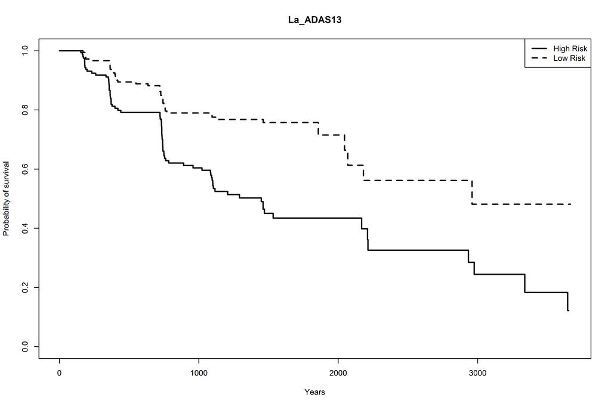

```r
par(cex=0.7)
s = Surv(DEdataframeTimeTrain$SurvTime, DEdataframeTimeTrain$status)
topvar <- univarDeTrain$orderframe$Name[1]
cmod <- coxph(formula(paste("Surv(SurvTime, status)~",topvar)),DEdataframeTimeTrain);
pmod <- predict(cmod,DEdataframeTimeTrain,type="lp")
pmor <- predict(cmod,DEdataframeTimeTrain,type="risk")
plot(survfit(s ~ pmod>0),main=topvar, xlab = "Years", ylab = "Probability of survival", lty=c(2,1), lwd=2)
legend("topright", legend = c("High Risk", "Low Risk"), lty =c(1,2), lwd=2)
```

```r
pLR=EmpiricalSurvDiff(DEdataframeTimeTrain$SurvTime,DEdataframeTimeTrain$status,pmod>0)
pander::pander(pLR$pvalue)
```

*1.63e-06*

```r
perdsurvTest <- cbind(DEdataframeTimeTrain$SurvTime,
                  DEdataframeTimeTrain$status,
                  pmod,
                  pmor)
prSurvTest <- predictionStats_survival(perdsurvTest,topvar,cex=0.75)
```

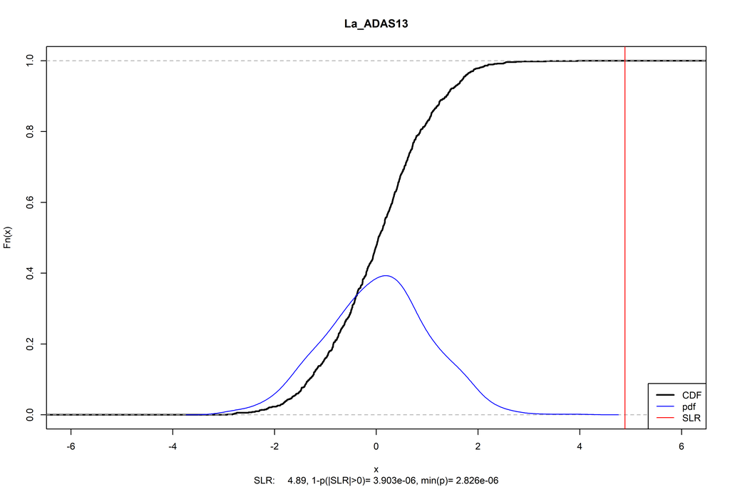

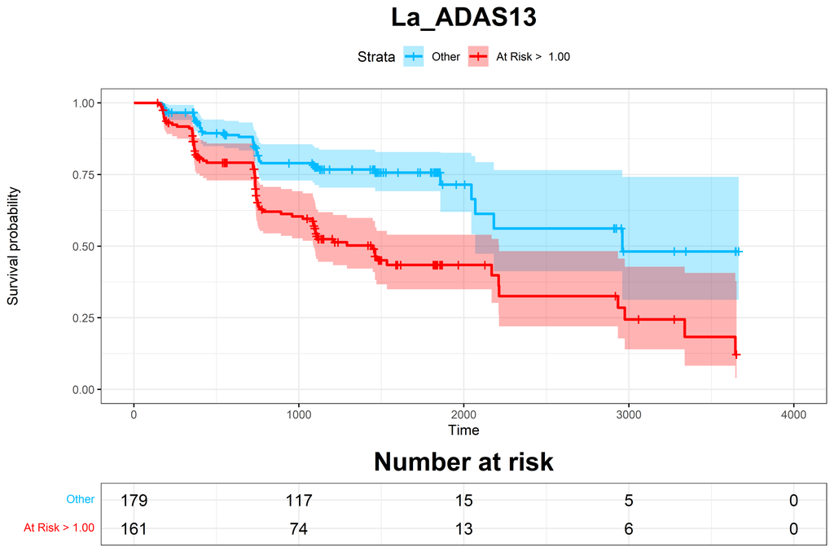

```r
pander::pander(survdiff(s ~ pmod>0))
```

Call: s ~ pmod > 0 Chisq = 23.843237 on 1 degrees of freedom, p = 0.000001

|  | N | Observed | Expected | (O-E)^2/E | (O-E)^2/V |
| --- | --- | --- | --- | --- | --- |
| **pmod > 0=FALSE** | 179 | 43 | 69.6 | 10.1 | 23.8 |
| **pmod > 0=TRUE** | 161 | 79 | 52.4 | 13.5 | 23.8 |

### 2.5.2 Test Univariate

```r
DEdataframeTime <- cbind(DEdataframe,SurvTime=surTimeTest)

#DEdataframe$surTime <- surTime



univarDetestAll <- uniRankVar(varlist_DeAll,
               paste("Surv(SurvTime,",outcome,")~1"),
               outcome,
               DEdataframeTime,
               categorizationType = "Raw",
               type = "COX",
               rankingTest = "Ztest",
                uniType = "Binary",
               timeOutcome="SurvTime")
```

```
#> 100 : M_ST24SA  200 : D_ST49TA  300 : La_D_ST47CV
```

```r
univarDetestAll$orderframe$pvalue=pnorm(abs(univarDetestAll$orderframe$ZGLM),lower.tail = FALSE)

pander::pander(univarDetestAll$orderframe[1:20,univariate_columns])
```

|  | caseMean | caseStd | controlMean | controlStd | controlKSP | cStatCorr | ZGLM | pvalue |
| --- | --- | --- | --- | --- | --- | --- | --- | --- |
| **FAQ** | 5.3852 | 5.10136 | 1.9128 | 3.09998 | 4.36e-14 | 0.254 | 8.39 | 2.41e-17 |
| **M_ST30SV** | 0.0892 | 0.01869 | 0.0761 | 0.01871 | 1.88e-01 | 0.309 | 7.55 | 2.12e-14 |
| **La_ADAS13** | 32.6864 | 5.67603 | 29.2522 | 4.54077 | 7.55e-01 | 0.333 | 7.40 | 6.87e-14 |
| **M_ST24TA** | 0.0265 | 0.00445 | 0.0295 | 0.00394 | 6.18e-02 | 0.692 | -7.33 | 1.12e-13 |
| **RAVLT_immediate** | 29.3361 | 7.43191 | 36.9128 | 11.13332 | 3.53e-01 | 0.741 | -7.23 | 2.36e-13 |
| **M_ST13TA** | 0.0192 | 0.00208 | 0.0205 | 0.00180 | 7.38e-01 | 0.669 | -6.89 | 2.78e-12 |
| **M_ST40SA** | 0.4645 | 0.02182 | 0.4787 | 0.02169 | 9.06e-01 | 0.657 | -6.14 | 4.02e-10 |
| **M_ST34TA** | 0.0196 | 0.00206 | 0.0210 | 0.00217 | 4.62e-01 | 0.647 | -6.03 | 8.00e-10 |
| **M_ST26SA** | 0.4619 | 0.02304 | 0.4779 | 0.02353 | 9.46e-01 | 0.654 | -5.96 | 1.29e-09 |
| **M_ST50CV** | 0.1216 | 0.00516 | 0.1248 | 0.00492 | 5.75e-01 | 0.645 | -5.81 | 3.12e-09 |
| **MMSE** | 26.7869 | 1.76855 | 27.8257 | 1.76418 | 1.20e-07 | 0.643 | -5.56 | 1.38e-08 |
| **M_ST46CV** | 0.1080 | 0.00507 | 0.1111 | 0.00485 | 7.94e-01 | 0.636 | -5.53 | 1.57e-08 |
| **M_ST32SA** | 0.4639 | 0.02719 | 0.4782 | 0.02558 | 7.61e-01 | 0.626 | -5.53 | 1.64e-08 |
| **La_M_ST40CV** | -0.0628 | 0.00681 | -0.0599 | 0.00579 | 4.66e-01 | 0.622 | -5.27 | 6.75e-08 |
| **M_ST21SV** | 0.1138 | 0.00589 | 0.1104 | 0.00669 | 9.93e-01 | 0.365 | 5.25 | 7.46e-08 |
| **M_ST35CV** | 0.1864 | 0.00730 | 0.1903 | 0.00825 | 4.77e-01 | 0.638 | -4.96 | 3.61e-07 |
| **M_ST47CV** | 0.1244 | 0.00714 | 0.1278 | 0.00701 | 4.38e-01 | 0.630 | -4.88 | 5.28e-07 |
| **M_ST44TA** | 0.0212 | 0.00288 | 0.0228 | 0.00331 | 6.05e-01 | 0.636 | -4.74 | 1.08e-06 |
| **M_ST31SA** | 0.5817 | 0.02679 | 0.5964 | 0.03029 | 6.35e-01 | 0.629 | -4.69 | 1.34e-06 |
| **La_WholeBrain** | 0.7345 | 0.01924 | 0.7444 | 0.01819 | 5.72e-01 | 0.599 | -4.52 | 3.14e-06 |

```r
univarDetest <- univarDetestAll
univarDetest$orderframe <- univarDetest$orderframe[varlistDe[,1],]
univarDetest$orderframe <- univarDetest$orderframe[order(univarDetest$orderframe$pvalue),]
pander::pander(univarDetest$orderframe[1:10,univariate_columns])
```

|  | caseMean | caseStd | controlMean | controlStd | controlKSP | cStatCorr | ZGLM | pvalue |
| --- | --- | --- | --- | --- | --- | --- | --- | --- |
| **La_ADAS13** | 32.686363 | 5.676028 | 29.25216 | 4.54077 | 0.755 | 0.333 | 7.40 | 6.87e-14 |
| **La_M_ST40CV** | -0.062783 | 0.006811 | -0.05989 | 0.00579 | 0.466 | 0.622 | -5.27 | 6.75e-08 |
| **La_WholeBrain** | 0.734532 | 0.019241 | 0.74442 | 0.01819 | 0.572 | 0.599 | -4.52 | 3.14e-06 |
| **La_M_ST51TA** | -0.000881 | 0.001300 | -0.00124 | 0.00106 | 0.499 | 0.370 | 4.21 | 1.28e-05 |
| **La_M_ST26CV** | -0.066899 | 0.006300 | -0.06413 | 0.00583 | 0.753 | 0.608 | -4.13 | 1.81e-05 |
| **La_M_ST14CV** | 0.007993 | 0.001728 | 0.00886 | 0.00166 | 0.971 | 0.605 | -4.12 | 1.89e-05 |
| **La_M_ST38TA** | 0.004168 | 0.000917 | 0.00454 | 0.00095 | 0.730 | 0.602 | -4.08 | 2.24e-05 |
| **La_M_ST29SV** | 0.150001 | 0.005235 | 0.15270 | 0.00575 | 0.762 | 0.610 | -3.97 | 3.57e-05 |
| **La_M_ST32CV** | -0.059211 | 0.007626 | -0.05686 | 0.00661 | 0.870 | 0.567 | -3.75 | 8.79e-05 |
| **La_M_ST129TA** | 0.011151 | 0.001547 | 0.01182 | 0.00143 | 0.893 | 0.598 | -3.56 | 1.88e-04 |

### 2.5.3 Survival plot of top feature

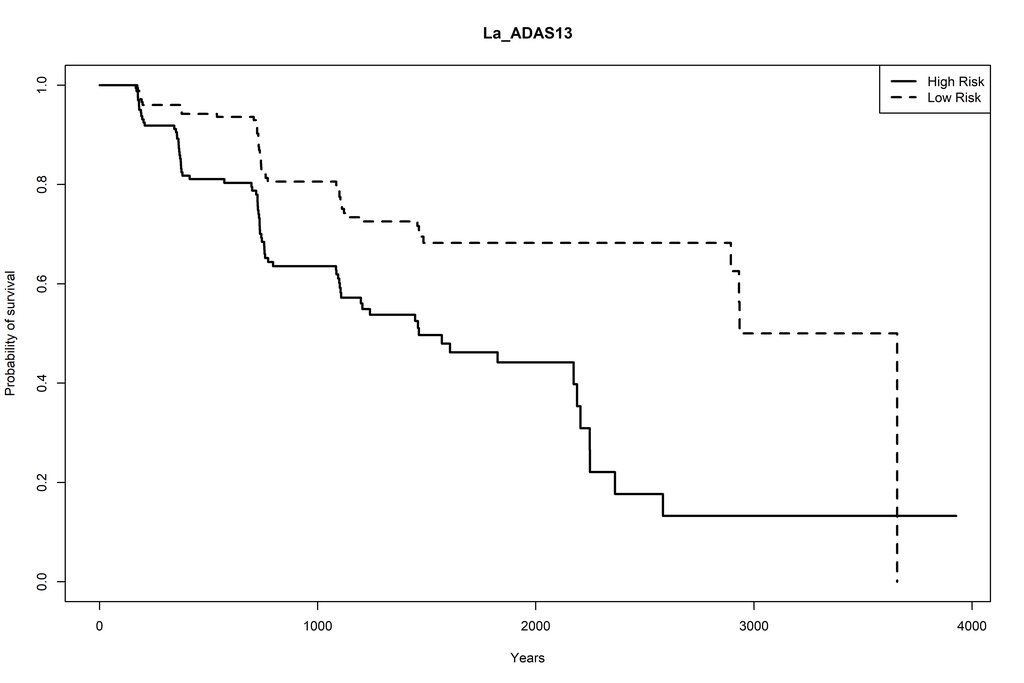

```r
par(cex=0.7)
s = Surv(DEdataframeTime$SurvTime, DEdataframeTime$status)
topvar <- univarDeTrain$orderframe$Name[1]
cmod <- coxph(formula(paste("Surv(SurvTime, status)~",topvar)),DEdataframeTimeTrain);
pmod <- predict(cmod,DEdataframeTime,type="lp")
pmor <- predict(cmod,DEdataframeTime,type="risk")
plot(survfit(s ~ pmod>0),main=topvar, xlab = "Years", ylab = "Probability of survival", lty=c(2,1), lwd=2)
legend("topright", legend = c("High Risk", "Low Risk"), lty =c(1,2), lwd=2)
```

```r
pLR=EmpiricalSurvDiff(DEdataframeTime$SurvTime,DEdataframeTime$status,pmod>0)
pander::pander(pLR$pvalue)
```

*5.01e-06*

```r
perdsurvTest <- cbind(DEdataframeTime$SurvTime,
                  DEdataframeTime$status,
                  pmod,
                  pmor)
prSurvTest <- predictionStats_survival(perdsurvTest,topvar,cex=0.75)
```

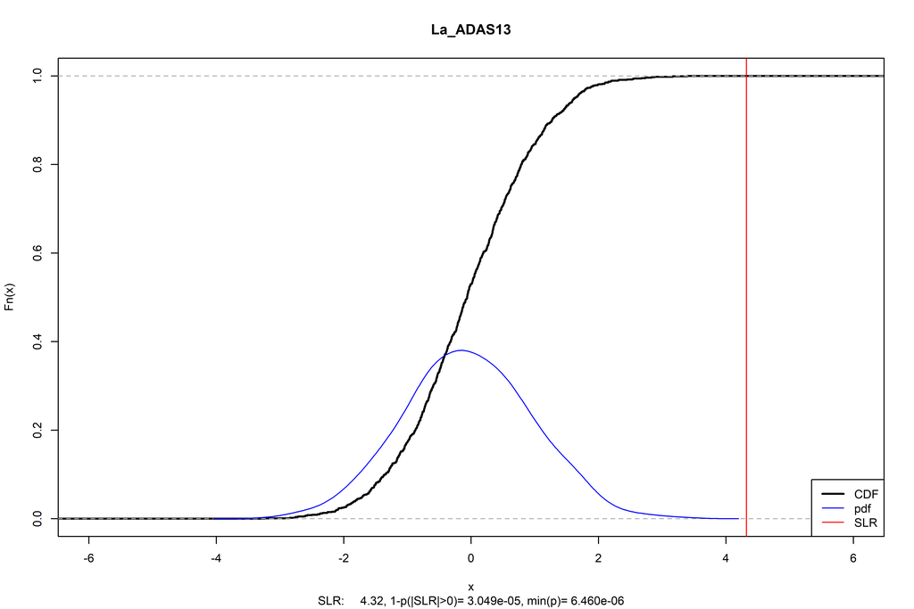

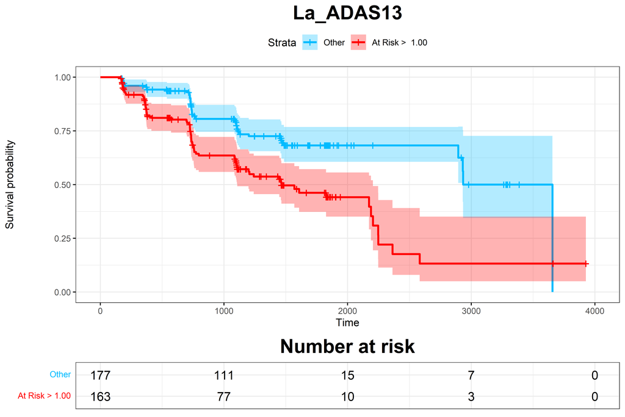

```r
pander::pander(survdiff(s ~ pmod>0))
```

Call: s ~ pmod > 0 Chisq = 18.624664 on 1 degrees of freedom, p = 0.000016

|  | N | Observed | Expected | (O-E)^2/E | (O-E)^2/V |
| --- | --- | --- | --- | --- | --- |
| **pmod > 0=FALSE** | 177 | 48 | 71.3 | 7.62 | 18.6 |
| **pmod > 0=TRUE** | 163 | 74 | 50.7 | 10.72 | 18.6 |

### 2.5.4 The Top Significant Figures

```r
pthr <- sig_pvalue/(ncol(dataframe)-1)

topDecorNames <- rownames(univarDeTrain$orderframe[univarDeTrain$orderframe$pvalue<pthr,])
topDecorNames <- unique(c(topDecorNames,rownames(univarDeTrain$orderframe[1:5,])))

dc <- getLatentCoefficients(DEdataframeTrain)
### 2a Get only the ones that in the top features
deNames_in_dc <- topDecorNames[topDecorNames %in% names(dc)]
selectedlist <- dc[deNames_in_dc]
theDeFormulas <- selectedlist


pander::pander(c(Average_Latent_Size=length(unlist(theDeFormulas))/length(theDeFormulas)))
```

| Average_Latent_Size |
| --- |
| 2.17 |

### 2.5.5 Final Table

```r
unlistdecorr <- selectedlist
names(unlistdecorr) <- NULL
unlistdecorr <- unique(names(unlist(unlistdecorr)))

finalTableDe <- univarDeTrain$orderframe[deNames_in_dc,univariate_columns]
finalTableDetest <- univarDetest$orderframe[deNames_in_dc,univariate_columns]

finalTable <- finalTableDetest

deFromula <- character(length(theDeFormulas))
names(deFromula) <- names(theDeFormulas)

for (dx in names(deFromula))
{
  coef <- theDeFormulas[[dx]]
  cname <- names(theDeFormulas[[dx]])
  names(cname) <- cname
  for (cf in names(coef))
  {
    if (cf != dx)
    {
      if (coef[cf]>0)
      {
        deFromula[dx] <- paste(deFromula[dx],
                               sprintf("+ %5.3f*%s",coef[cf],cname[cf]))
      }
      else
      {
        deFromula[dx] <- paste(deFromula[dx],
                               sprintf("%5.3f*%s",coef[cf],cname[cf]))
      }
    }
  }
}
orgnamez <- rownames(finalTable)
orgnamez <- str_remove_all(orgnamez,"Ba_")
orgnamez <- str_remove_all(orgnamez,"La_")
finalTable$Train_ZGLM <- finalTableDe[rownames(finalTable),"ZGLM"]
finalTable$Train_cStatCorr <- finalTableDe[rownames(finalTable),"cStatCorr"]
finalTable$pvalue <- pnorm(abs(finalTable$ZGLM),lower.tail = FALSE)
finalTable$uZGLM <- univar$orderframe[orgnamez,"ZGLM"]
finalTable$DecorFormula <- deFromula[rownames(finalTable)]
fscores <- attr(DEdataframeTrain,"fscore")
finalTable$fscores <- fscores[rownames(finalTable)]

finalTable <- finalTable[order(finalTable$pvalue),]
finalTable$ROCAUC <- NULL
finalTable$kendall.p <- NULL
pander::pander(finalTable)
```

|  | caseMean | caseStd | controlMean | controlStd | controlKSP | cStatCorr | ZGLM | pvalue | Train_ZGLM | Train_cStatCorr | uZGLM | DecorFormula | fscores |
| --- | --- | --- | --- | --- | --- | --- | --- | --- | --- | --- | --- | --- | --- |
| **La_ADAS13** | 32.68636 | 5.676028 | 29.252163 | 4.540772 | 0.755 | 0.333 | 7.399 | 6.87e-14 | 6.81 | 0.334 | 10.25 | + 1.000*ADAS13 + 0.405*RAVLT_immediate | 0 |
| **La_M_ST40CV** | -0.06278 | 0.006811 | -0.059888 | 0.005787 | 0.466 | 0.622 | -5.272 | 6.75e-08 | -4.30 | 0.608 | -9.48 | -0.280*WholeBrain + 1.000*M_ST40CV | -1 |
| **La_M_ST29SV** | 0.15000 | 0.005235 | 0.152698 | 0.005745 | 0.762 | 0.610 | -3.972 | 3.57e-05 | -6.45 | 0.642 | -7.56 | + 1.000*M_ST29SV + 0.275*M_ST30SV | 1 |
| **La_RAVLT_forgetting** | 1.08550 | 1.527090 | 1.476359 | 1.509608 | 0.534 | 0.628 | -3.265 | 5.48e-04 | -5.14 | 0.628 | 2.49 | + 1.000*RAVLT_forgetting -0.055*RAVLT_perc_forgetting | -1 |
| **La_M_ST39SA** | 0.15266 | 0.009177 | 0.157081 | 0.010566 | 0.253 | 0.576 | -2.864 | 2.09e-03 | -4.06 | 0.612 | -3.44 | + 5.202*M_ST39TA + 1.000*M_ST39SA -2.161*M_ST39CV | -2 |
| **La_M_ST31TA** | 0.00069 | 0.000842 | 0.000716 | 0.000697 | 0.924 | 0.515 | -0.756 | 2.25e-01 | -4.70 | 0.606 | -6.58 | + 1.000*M_ST31TA -0.937*M_ST59TA | -1 |

```r
save(finalTable,file=paste("FinalTable",thr,method,type,DeOutcome,corRankS,".RDATA",sep="_"))
```

### 2.5.6 The bhattacharyya between the two classes: TRAIN

```r
par(op)
par(mfrow=c(1,2),cex=0.9)

pvals <- univarTrain$orderframe$pvalue
names(pvals) <- rownames(univarTrain$orderframe)
praw <- p.adjust(pvals,method="BH")
topSigRaw <- names(praw[praw<sig_pvalue])


pvalsDe <- univarDeAllTrain$orderframe$pvalue
names(pvalsDe) <- rownames(univarDeAllTrain$orderframe)
pDe <- p.adjust(pvalsDe,method="BH")
topSigDe <- names(pDe[pDe<sig_pvalue])

pDeDe <- pDe[names(pDe) %in% varlistDe[,1]]
pDeDe <- pDeDe[pDeDe<sig_pvalue]

pander::pander(c(Raw_Significant=length(topSigRaw),La_Significant=length(topSigDe),SigDe=length(pDeDe)))
```

| Raw_Significant | La_Significant | SigDe |
| --- | --- | --- |
| 101 | 43 | 11 |

```r
sig_p <- min(c(sig_pvalue,1.0e4*praw[10]))

praw <- praw[praw <= sig_p]

pander::pander(c(Raw_Significant=length(praw),Pvalue=sig_p))
```

| Raw_Significant | Pvalue |
| --- | --- |
| 26 | 1.3e-08 |

```r
pander::pander(as.matrix(praw))
```

| **ADAS13** | 6.54e-26 |
| --- | --- |
| **FAQ** | 8.97e-21 |
| **ADAS11** | 2.06e-20 |
| **M_ST12SV** | 4.85e-15 |
| **RAVLT_immediate** | 1.17e-14 |
| **Hippocampus** | 2.31e-14 |
| **M_ST29SV** | 2.31e-14 |
| **M_ST13TA** | 2.61e-13 |
| **M_ST40CV** | 3.50e-13 |
| **M_ST24CV** | 1.30e-12 |
| **M_ST24TA** | 2.76e-12 |
| **M_ST40TA** | 8.53e-12 |
| **RAVLT_perc_forgetting** | 1.26e-11 |
| **M_ST31TA** | 3.36e-11 |
| **RAVLT_learning** | 2.73e-10 |
| **M_ST32TA** | 2.73e-10 |
| **M_ST52TA** | 3.69e-10 |
| **M_ST56CV** | 1.27e-09 |
| **M_ST32CV** | 1.48e-09 |
| **M_ST129CV** | 1.52e-09 |
| **M_ST26TA** | 1.65e-09 |
| **M_ST31CV** | 1.68e-09 |
| **MMSE** | 3.03e-09 |
| **M_ST58CV** | 4.67e-09 |
| **M_ST58TA** | 4.67e-09 |
| **WholeBrain** | 7.38e-09 |

```r
if (sum(pDe <= sig_p)>1)
{
  pDe <- pDe[pDe <= sig_p]
} else
{
  pDe <- pDe[1:2]
}

topvarraw <- names(praw)


subcases <- subset(dataframe,get(outcome)==1)
subcontrols <- subset(dataframe,get(outcome)==0)


casesCov <- MASS::cov.rob(subcases[,topvarraw])
meanCases <- casesCov$center
covCases <- casesCov$cov

controlsCov <- MASS::cov.rob(subcontrols[,topvarraw])
meanControls <- controlsCov$center
covControls <- controlsCov$cov


distRaw <- bhattacharyya.dist(meanCases, meanControls, covCases, covControls)
maha1 <- mahalanobis(meanCases,meanControls,covControls)
maha2 <- mahalanobis(meanControls,meanCases,covCases)
mahaDisRaw <- sqrt(0.5*(maha1+maha2))

disttoControl <- mahalanobis(dataframeTest[,topvarraw],meanControls,covControls)
disttoCases <- mahalanobis(dataframeTest[,topvarraw],meanCases,covCases)
pbMaha <- predictionStats_binary(cbind(dataframeTest[,outcome],disttoControl-disttoCases),"Raw Maha:ROC",cex=0.8)
```

Raw Maha:ROC

```r
#mlNB <- NAIVE_BAYES(formula(paste(outcome,"~.")),dataframe[,c(outcome,topvarraw)],pca=FALSE)
#pb <- predictionStats_binary(cbind(dataframeTest[,outcome],predict(mlNB,dataframeTest[,c(outcome,topvarraw)])),"Raw NB:ROC")
#mlSig <- CVsignature(formula(paste(outcome,"~.")),dataframe[,c(outcome,topvarraw)])
#pb <- predictionStats_binary(cbind(dataframeTest[,outcome],predict(mlSig,dataframeTest[,c(outcome,topvarraw)])),"Raw Sig:ROC")

### Decorrelated Analysis

subcases <- subset(DEdataframeTrain,get(outcome)==1)
subcontrols <- subset(DEdataframeTrain,get(outcome)==0)


topvarDe <- names(pDe)
pander::pander(c(Decorrelated_Significant=length(pDe)))
```

| Decorrelated_Significant |
| --- |
| 7 |

```r
pander::pander(as.matrix(pDe))
```

| **FAQ** | 1.79e-20 |
| --- | --- |
| **RAVLT_immediate** | 2.93e-14 |
| **M_ST13TA** | 6.97e-13 |
| **M_ST24TA** | 7.58e-12 |
| **La_ADAS13** | 3.12e-10 |
| **La_M_ST29SV** | 3.09e-09 |
| **MMSE** | 9.95e-09 |

```r
casesCov <- MASS::cov.rob(subcases[,topvarDe])
meanCases <- casesCov$center
covCases <- casesCov$cov

controlsCov <- MASS::cov.rob(subcontrols[,topvarDe])
meanControls <- controlsCov$center
covControls <- controlsCov$cov


distDe <- bhattacharyya.dist(meanCases, meanControls, covCases, covControls)

maha1 <- mahalanobis(meanCases,meanControls,covControls)
maha2 <- mahalanobis(meanControls,meanCases,covCases)
mahaDisDe <- sqrt(0.5*(maha1+maha2))


disttoControl <- mahalanobis(DEdataframe[,topvarDe],meanControls,covControls)
disttoCases <- mahalanobis(DEdataframe[,topvarDe],meanCases,covCases)
pbMaha <- predictionStats_binary(cbind(DEdataframe[,outcome],disttoControl-disttoCases),"De Maha:ROC",cex=0.8)
```

De Maha:ROC

[figure not shown]

```r
mlKNNRaw <- KNN_method(formula(paste(outcome,"~.")),dataframe[,c(outcome,topSigRaw)])
pbKNN <- predictionStats_binary(cbind(dataframeTest[,outcome],predict(mlKNNRaw,dataframeTest[,c(outcome,topSigRaw)])),"Raw KNN:ROC",cex=0.8)
```

Raw KNN:ROC

```r
pander::pander(pbKNN$aucs)
```

| est | lower | upper |
| --- | --- | --- |
| 0.777 | 0.727 | 0.827 |

```r
pander::pander(pbMaha$aucs)
```

| est | lower | upper |
| --- | --- | --- |
| 0.805 | 0.756 | 0.853 |

```r
mlKNN <- KNN_method(formula(paste(outcome,"~.")),DEdataframeTrain[,c(outcome,topSigDe)])
pbKNN <- predictionStats_binary(cbind(dataframeTest[,outcome],predict(mlKNN,DEdataframe[,c(outcome,topSigDe)])),"De KNN:ROC",cex=0.8)
```

De KNN:ROC

[figure not shown]

```r
pander::pander(c(Raw_Bhattacharyya=distRaw,Raw_Mahalanobis=mahaDisRaw))
```

| Raw_Bhattacharyya.modulus | Raw_Mahalanobis |
| --- | --- |
| 1.93 | 2.82 |

```r
pander::pander(c(La_Bhattacharyya=distDe,La_Mahalanobis=mahaDisDe))
```

| La_Bhattacharyya.modulus | La_Mahalanobis |
| --- | --- |
| 0.918 | 2.67 |

```r
pander::pander(pbKNN$aucs)
```

| est | lower | upper |
| --- | --- | --- |
| 0.793 | 0.746 | 0.841 |

```r
pander::pander(pbMaha$aucs)
```

| est | lower | upper |
| --- | --- | --- |
| 0.805 | 0.756 | 0.853 |

### 2.5.7 Comparing the ROC KNN Train Test curves

```r
par(op)
par(mfrow=c(1,2),cex=0.8)

pbKNNTrain <- predictionStats_binary(cbind(dataframe[,outcome],predict(mlKNN,DEdataframeTrain[,c(outcome,topSigDe)])),"De Train KNN:ROC",cex=0.8)
```

De Train KNN:ROC

```r
pbKNNTest <- predictionStats_binary(cbind(dataframeTest[,outcome],predict(mlKNN,DEdataframe[,c(outcome,topSigDe)])),"De Test KNN:ROC",cex=0.8)
```

De Test KNN:ROC

[figure not shown]